# Chapter 7: Comparing a Numerical Variable Across Two Groups

In this chapter, we will consider methods that allow us to make comparisons on numerical variables between two different groups. In general, these methods should be used to address research questions involving a *categorical explanatory* variable (with two categories) and a *numerical response* variable.

Two different cases will be considered:

1. When the samples are independent, and
2. when the samples are dependent (i.e., matched or paired).

## COMPARING TWO POPULATION MEANS: INDEPENDENT SAMPLES (two-sample independent t-test)

The hypothesis testing procedures presented in this section should be used when the observations from the two groups being compared are *independent*. Whether or not the observations between the two groups are *independent* is determined by how the data are collected. To see this, consider the following example.

### Example 7.1: Nicotine withdrawal and Perceived Elapsed Time

Recall the study conducted by researchers at Pennsylvania State University which investigated whether time perception, a simple indication of a person’s ability to concentrate, is impaired during nicotine withdrawal. This study was discussed in Chapter 6. Twenty smokers were put through a 24-hour smoking abstinence and were asked to estimate how much time had passed during a 45-second period. Then, we analyzed another 22 individuals who were daily smokers, but were not asked to abstain from smoking for 24-hours (i.e., no nicotine withdrawal). They were also asked to estimate how much time had passed during a 45-second period. Suppose the resulting data on perceived elapsed time (in seconds) were collected from both groups as shown below (these results are artificial but are similar to the actual findings).

```r
head(time_elapsed)
```

```
# A tibble: 6 × 4
  status        sex      age time_passed
  <chr>         <chr>  <dbl>       <dbl>
1 no withdrawal male      42        42.5
2 no withdrawal male      40        41.2
3 no withdrawal male      45        51.7
4 withdrawal    male      31        59.9
5 withdrawal    female    42        52.6
6 withdrawal    male      32        42.8
```

**Research Question**: Do daily smokers suffering from nicotine withdrawal tend to believe that more time has elapsed than daily smokers *not* suffering from nicotine withdrawal?

1. What is the observational unit for this study?
2. What are the variables assessed in this study? What are their roles (explanatory / response) and data types?
3. What are the parameters of interest for this study?

Similar to summarizing a single numeric variable, we can compare the two groups with summary statistics from the `favstats()` function.

```r
favstats(time_passed ~ status, data = time_elapsed)
```

**1**

Using the `favstats` function, denote the `response ~ explanatory` variables from the `data =` set.

```
         status   min      Q1 median      Q3   max    mean       sd  n missing
1 no withdrawal 30.86 41.2375 45.865 49.4625 61.21 45.2200 6.826466 22       0
2    withdrawal 39.12 48.7450 53.260 56.6575 69.37 52.6535 7.268202 20       0
```

4. Report the observed mean perceived time passed for study participants suffering from nicotine withdrawal. How about for participants *not* suffering from nicotine withdrawal?
5. Calculate the observed sample difference in the mean perceived time elapsed between participants suffering nicotine withdrawal and participants not suffering nicotine withdrawal.

**Facetted Histograms**

When we want to add a categorical variable (like withdrawal status) to a histogram, we can create separate plots for each level of the categorical variable. These separate plots are called facets. We are comparing the perceived time passed between participants suffering withdrawal and participants not suffering withdrawal, so we will have two facets, one per status.

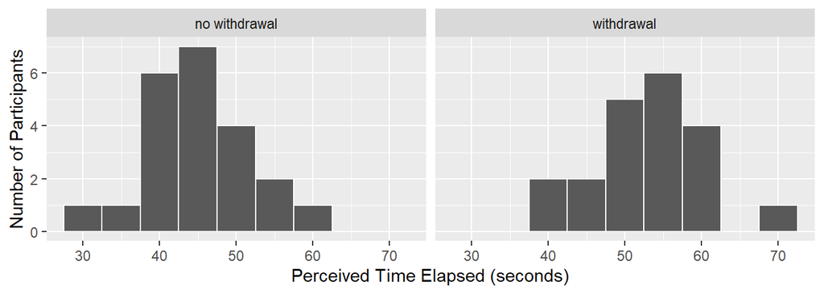

```r
ggplot(data = time_elapsed,
       mapping = aes(x = time_passed)) +
  geom_histogram(binwidth = 5, color = "white") +
  labs(x = "Perceived Time Elapsed (seconds)",
       y = "Number of Participants") +
  facet_wrap(~ status)
```

**Side-by-Side Box Plots**

Another way we can incorporate a categorical into our plots is to plot our boxplots for each group side-by-side. As opposed to faceting, these boxplots will be on the **same** plot. We only need to add one extra piece to our code from the previous chapter: a categorical variable.

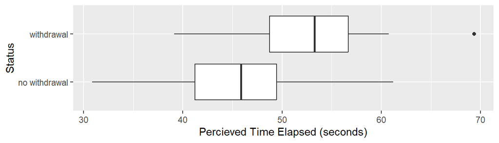

```r
ggplot(data = time_elapsed,
       mapping = aes(x = time_passed,
                     y = status)) +
  geom_boxplot() +
  labs(x = "Percieved Time Elapsed (seconds)",
       y = "Status")
```

Now that we have explored our data with summary statistics and visualizations, we want to use our data to draw inferences and make claims about the larger population.

Since we know the difference will change from sample to sample, in order to make valid inferences about the true population difference, we must first understand how the difference in sample means is expected to change from sample to sample. That is, we must determine what differences in means are likely to happen by chance when taking random samples from populations with the same mean.

6. Set up the null and alternative hypotheses (in words and symbols).

In order to test our research question, we could conduct a simulation similar to what we did with two categorical variables (e.g., Mythbusters yawn experiment). Recall, we follwed the following steps:

- Step 1: Write the ____________ and ____________ on ______ cards.
- Step 2: Simulate what could have happened if the null was true and ________________.
- Step 3: Generate a new data set by _________________________________.
- Step 4: Calculate the ____________________________ for the new simulated data set and add it to the dot plot.

We would then repeat this process 100 or 1000 times to get an idea of what the sampling distribution of the *difference* in means between the two groups looks like.

7. Assuming there is *no difference* in mean percieved time elapsed between participants suffering from nicotine withdrawal and participants not suffering from nicotine withdrawal (i.e., Null is true), where do you expect the distribution to be centered? Explain.

The plot below contains 19 panels of “new simulated” data sets under the assumption there is no difference in mean perceived time elapsed between the two groups (i.e., Null is true), following the process above, and one panel of the actual data observed from the sample of 42 daily smokers in our study.

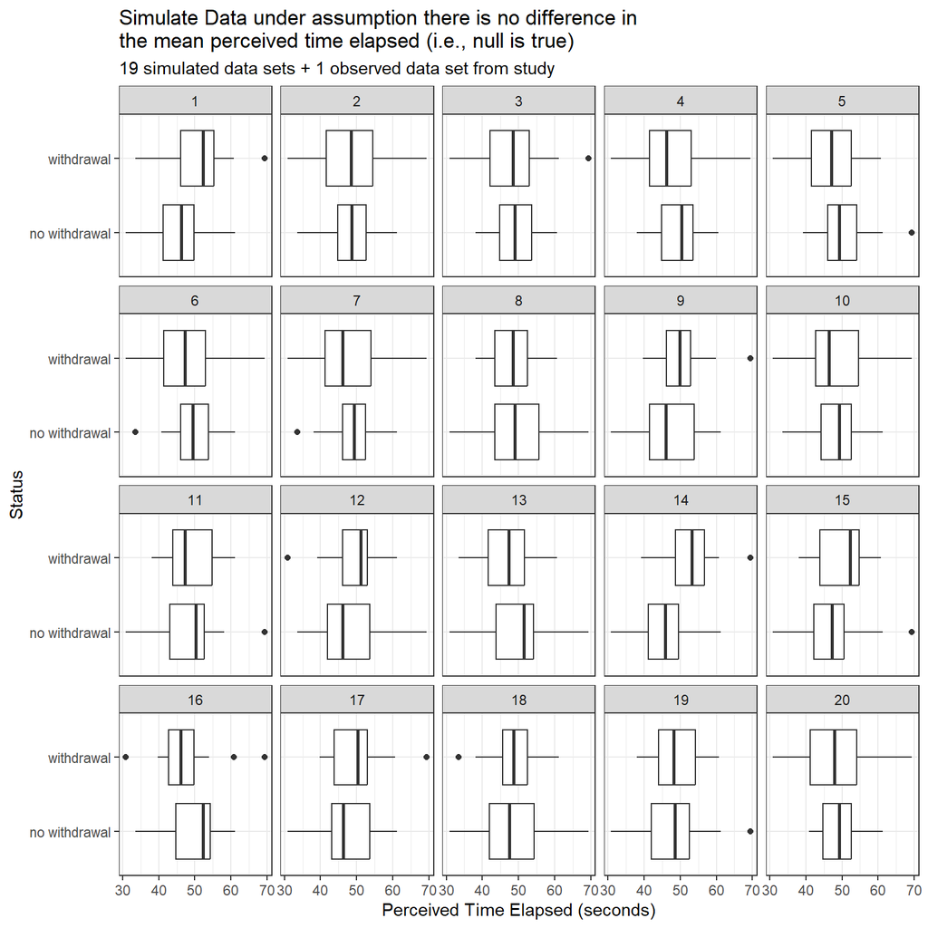

8. Which panel contains the actual data observed in the sample of 42 daily smokers in our study? Was it hard to pick out? Remember what it was like trying to pick this out.

We could take these and calculate the observed difference in mean perceived elapsed time between the two groups for each panel and plot this to begin creating the distribution of our sampling difference in means.

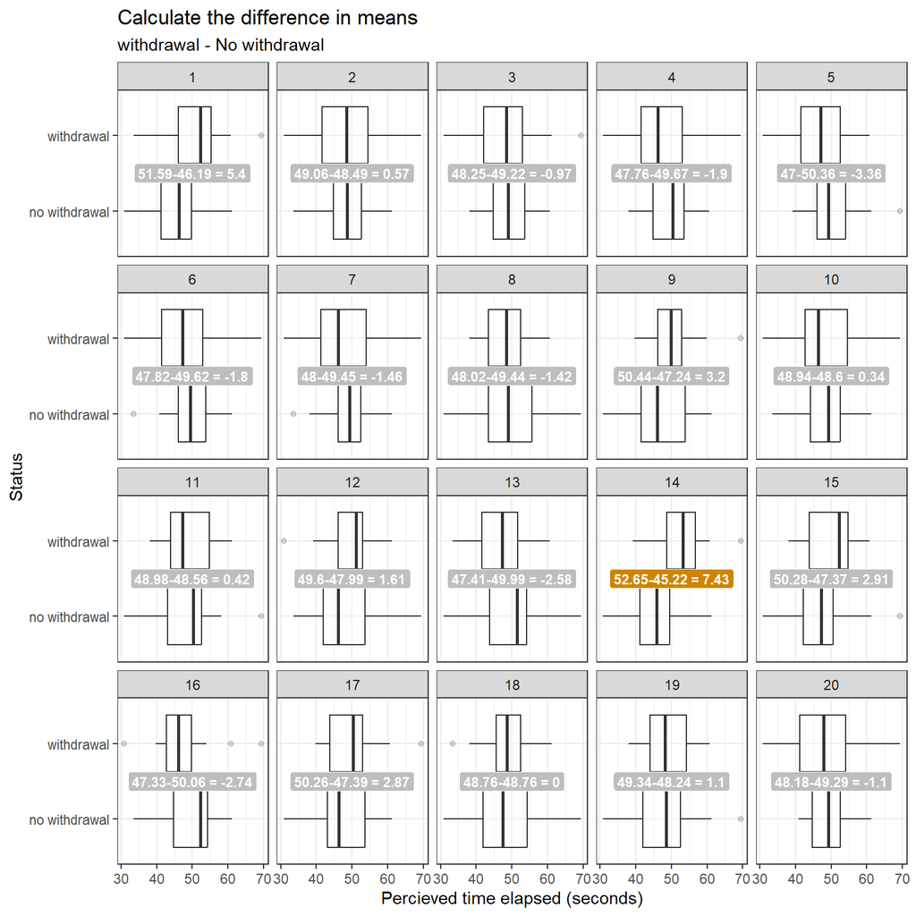

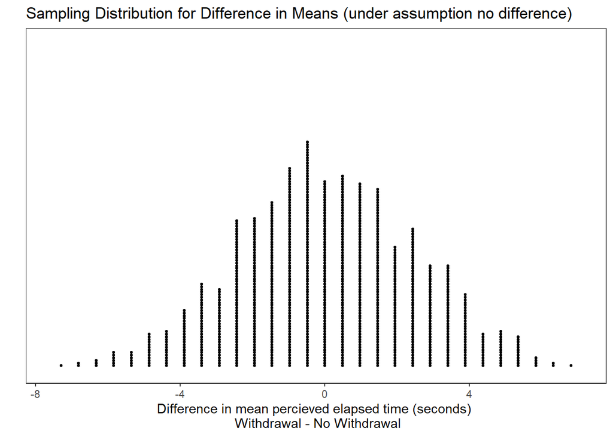

9. Does our observed data appear to be unusual compared to the data simulated under the assumption there is no difference?

It turns out that these sample means vary in a predictable way, and we can use what we know about this predictable pattern to determine what outcomes are likely (or not likely) to happen by chance. This predictable pattern is called the *sampling distribution for the difference in means*.

**Characteristics for Sampling Distribution for Difference in Means**

When the samples are **independent**, the sampling distribution for the difference in means can be described as follows.

1. mean = $\mu_1 – \mu_2$.
2. standard deviation of the sampling distribution (i.e., standard error) =
   $$\sqrt{\frac{s_1^2}{n_1} + \frac{s_2^2}{n_2}}$$

*Note: we are assuming the variances are unequal in this calculation, there are other formulas for assuming equal variances.*

3. The shape of the sampling distribution is approximately normal if both sample sizes are “sufficiently large” (> 30 in each group) OR if both original populations are normally distributed.

Given these characteristics, the test statistic we will use when testing for differences in two population means for independent samples is as follows:

$$T= \frac{\text{observed value}-\text{null value}}{\text{standard error}}= \frac{(\bar x_1 - \bar x_2)-(\mu_1 - \mu_2)}{\sqrt{\frac{s_1^2}{n_1} + \frac{s_2^2}{n_2}}}$$

These test statistics both follow a t-distribution, and the degrees of freedom are given by $(n_1 - 1) +(n_2 - 1)$.

*Note: there are more complicated ways to adjust for these degrees of freedom, but that is beyond the scope of this class. You may notice that R outputs a different number of degrees of freedom than what this formula gives you.*

10. Calculate the observed T test-statistic for the study data.
11. Using the t-distribution provided below, show how you would estimate the p-value.

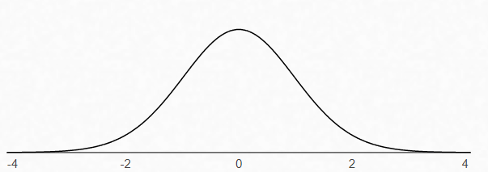

Additionally, we can use R to conduct our two-sample independent t-test to answer our research question.

```r
t_test(x = time_elapsed,
       explanatory = status,
       response = time_passed,
       order = c("withdrawal", "no withdrawal"),
       #mu = 0,
       alternative = "greater",
       conf_int = FALSE)
```

**1**

Using the `t_test()` function, designate the `x =` data set.

**2**

Then identify the `explanatory =` variable,

**3**

and the `response =` variable.

**4**

The `order = c("Group 1","Group 2")` we are testing is $\mu_1 - \mu_2$,

**5**

with an `alternative =` upper tailed test.

**6**

Let’s hide the confidence interval, `conf_int = FALSE`, output for now.

```
# A tibble: 1 × 5
  statistic  t_df  p_value alternative estimate
      <dbl> <dbl>    <dbl> <chr>          <dbl>
1      3.41  39.0 0.000768 greater         7.43
```

12. Write the conclusion in context of the problem. Make sure to include your evidence.

**Conditions for two-sample independent t-test**

1. Independent observations *between* groups.
2. Independent observations *within* groups.
3. Sufficiently large sample sizes in both groups (i.e., $n_1>30$ and $n_2>30$). If not, is it reasonable to assume that both populations are normally distributed?
13. Check the conditions for using the two-sample independent t-test.
14. Can we say that nicotine withdrawal *causes* a longer perceived elapsed time? Explain.